# Week 05 Problem Set: Data Import and Tidy Data

Sami Cemek

## Getting started

Add the code to load the Lock5Data and tidyverse packages in the code chunk at the start of this document.

Please remember not to print data sets unless a question specifically asks you to.

## EE1 Tidy data

Consider the following data containing a log of the number of different hawks observed at a hawk blind.

```r
hawk_data <- tribble(
  ~Species, ~Adult, ~Immature,
  "Cooper",      32,      38,
  "Red-Tailed",  123,    454,
  "Sharp-shinned", 69,   192
)
hawk_data
```

```
## # A tibble: 3 x 3
##   Species       Adult Immature
##   <chr>         <dbl>    <dbl>
## 1 Cooper           32       38
## 2 Red-Tailed      123      454
## 3 Sharp-shinned    69      192
```

1. Explain why this is not “tidy data”. To fix it, do we need to make it wider or longer? What are the variables?

**Your answer:** This is not “tidy” data because we can make the data set longer by adding a new column that sorts by maturity.

2. Use the appropriate code to make the data tidy (longer). Print the tidy data set.

```r
tidy_hawk_data <- hawk_data %>%
  pivot_longer(names_to = "Maturity",
               values_to = "Number",
               cols = c(Adult, Immature))
tidy_hawk_data
```

```
## # A tibble: 6 x 3
##   Species       Maturity Number
##   <chr>         <chr>     <dbl>
## 1 Cooper        Adult        32
## 2 Cooper        Immature     38
## 3 Red-Tailed    Adult       123
## 4 Red-Tailed    Immature    454
## 5 Sharp-shinned Adult        69
## 6 Sharp-shinned Immature    192
```

## EE 2 Data import excel

Find the spreadsheet of data on all 50 US states, “us_state.xlsx” included in the Week05Exercises folder. Open the spreadsheet in Excel (or numbers) and explore its structure.

Write code to import the 2011 data, making sure that NA values are treated appropriately. Create a histogram of the percentage of residents who have competed in a physical activity in past month (`PhysicalActivity`).

```r
#Import excel data set
library(readxl)
```

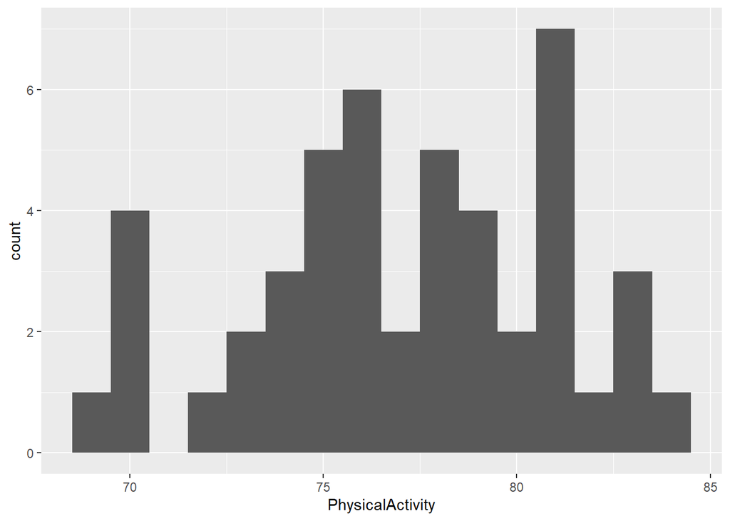

```r
us_state <- read_excel("us_state.xlsx", sheet = "2011",
    na = "-999", skip = 2)
View(us_state)

#Remove NA cases
us_state_complete <- us_state[complete.cases(us_state),]

#Make a histogram
ggplot(us_state_complete, aes(x=PhysicalActivity)) + geom_histogram(binwidth = 1)
```

## EE3 Tidy data visualization

```r
head(CityTemps)
```

```
##   Year Month Moscow Melbourne San.Francisco
## 1 2017     1   -7.8      21.1          10.3
## 2 2017     2   -4.6      19.8          12.5
## 3 2017     3    2.4      21.1          13.9
## 4 2017     4    5.3      15.8          14.7
## 5 2017     5   10.9      12.1          16.1
## 6 2017     6   14.4       9.4          17.3
```

1. I’d like to make side-by-side boxplots of the temperatures in all three cities. I want the boxplots to all be on the same scale, in the same graph. Is it possible to do this with the data in its current form? If so, please do so. If not, explain why not.

**Your Answer:** It’s not possible because if we want to make side by side boxplots(all be on the same scale, in the same graph) we need to tidy our data set. The reason for this is because: x axis variable need to be categorical. We can do that combining city names as a categorical variable. We can make separate boxplots with the current data set.

```r
#Nothing goes here
```

2. Let’s try to tidy the data. I’d like to have a longer data set, which includes the columns Year, Month, City, Temperature. It would look something like this:

| Year | Month | City | Temperature |
| --- | --- | --- | --- |
| 2014 | 1 | Moscow | -8.6 |
| 2014 | 1 | Melbourne | 22 |
| 2014 | 1 | San.Francisco | 12.8 |
| 2014 | 2 | Moscow | -1.9 |
| … | … | … | … |

Write the code to restructure CityTemps into this tidy form. Save the data as `TidyTemps`

**Your Answer:**

```r
TidyTemps <- CityTemps %>%
  pivot_longer(names_to = "City",
               values_to = "Temperature",
               cols = c(Moscow,Melbourne,San.Francisco))
head(TidyTemps)
```

```
## # A tibble: 6 x 4
##    Year Month City          Temperature
##   <int> <int> <chr>               <dbl>
## 1  2017     1 Moscow               -7.8
## 2  2017     1 Melbourne            21.1
## 3  2017     1 San.Francisco        10.3
## 4  2017     2 Moscow               -4.6
## 5  2017     2 Melbourne            19.8
## 6  2017     2 San.Francisco        12.5
```

3. Use your new TidyTemps data to make side-by-side boxplots of the temperatures in all three cities.

**Your Answer:** See the graph below.

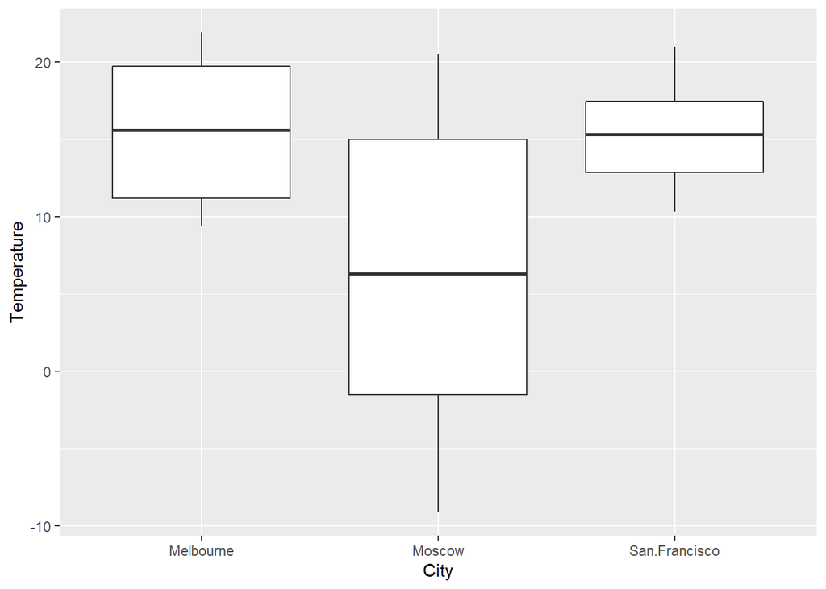

```r
ggplot(TidyTemps, aes(x=City,y=Temperature)) + geom_boxplot()
```

4. What if you wanted to make a scatterplot of the Moscow temperatures and the San Francisco temperatures? Which data set (CityTemps or TidyTemps) would be more useful? Write the code to create this scatterplot.

**Your Answer:** I think it would be better and easier to use CityTemps because we have separate variables for each cities.

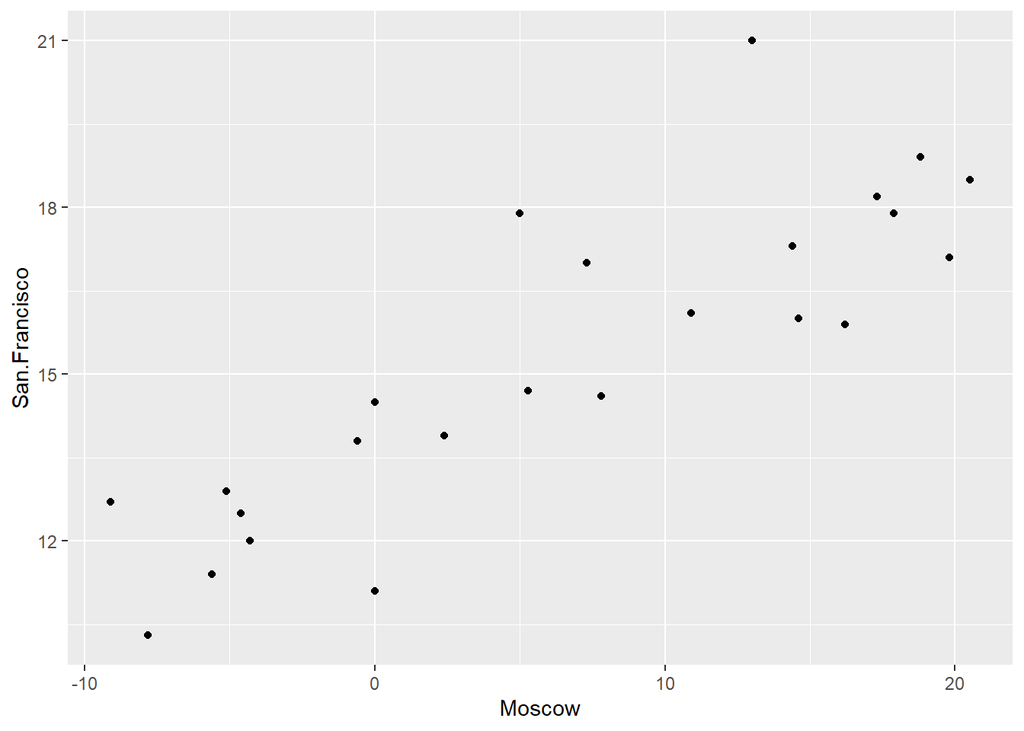

```r
ggplot(CityTemps, aes(x=Moscow,y=San.Francisco)) + geom_point()
```

## EE4 book exercise from R4DS Ch 12

What would happen if you widen this table? Why? How could you add a new column to uniquely identify each value?

```r
people <- tribble(
  ~name,             ~key,    ~value,
  #-----------------|--------|------
  "Phillip Woods",   "age",       45,
  "Phillip Woods",   "height",   186,
  "Phillip Woods",   "age",       50,
  "Jessica Cordero", "age",       37,
  "Jessica Cordero", "height",   156
)
```

## EE 5 OPTIONAL Messy data import messages

Suppose you realize at this point that you are going to need the chicago csv for this assignment. You also decide you want to use the `mosaic` package to help explore this data (FYI, I’m a big fan of the `favstats()` function in that package).

1. Write the code in the code chunk below to load the mosaic package and import the chicago data. Then use favstats() to create a summary of the daily temperature `tempd` (code included; just un-comment it).

```r
#favstats(~tmpd, data = chicago)
```

2. Knit the document and describe the output from your previous code chunk.

3. Explore [chunk options](https://rmarkdown.rstudio.com/lesson-3.html) that would let you clean up the output. Change the chunk options in the code chunk in part a. Knit the document again and verify that there are no messages, warnings, etc. from R when you import your data. Describe what options allowed you to do this.

## EE 6 OPTIONAL Challenging graphs

As a bonus for intermediate R users, try using the chicago data to recreate the following graphs.

#### EE6a Monthly averages of each pollutant

```r
library(tidyverse)
library(readr)
library(lubridate)
#I commented out my code for this question to knit the file. I don't know why it doesn't work.

chicago <- read_csv("chicago.csv")
```

```r
#View(chicago)

#tidychicago <- chicago %>%
#  mutate(month = month(date)) %>% #Doesn't work???
#  group_by(month) %>%
#  summarize(mean_pm25 = mean(pm25tmean2), mean_ozone = mean(o3tmean2), mean_no2 = mean(no2tmean2))

#pivot_longer(names_to = "pollutant",
#               values_to = "measurement",
#               cols = c(mean_pm25, mean_ozone, mean_no2))
#head(tidychicago)

#ggplot(tidychicago, aes(x=month,y=measurement,color=pollutant)) + geom_line()
```

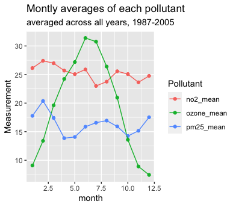

#### EE6b pm10 comparison from 1987 to 2005

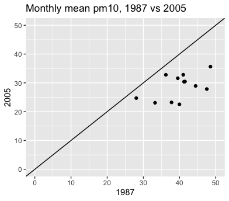